# Kernels

Kernels as we have seen in the eariler articles, are essential part of a GP. They are also losely called covariance functions, which measure similarity between 2 points. They can be defined using any of the mechanics in mathematics, obeying some rules which will be discussed later.

In addition, it should exhibit the property where the kernel will return a larger value when close and smaller value when far. We had intentionally not define close and far as that is the responsibility of the kernel.

A simple kernel can be simply be defined by cosine similarity: $$ k(x,y) = \frac{x\cdot y}{|x||y|} $$

Such a kernel measures distance in eculidean(L2) space. We experiment this with 2 points: $x=[0, 1]$ and $y=[1, 0]$. These 2 points are not similar, so they should get a low value. We expect the value $0$, from computing the cosine equation.

```python
import warnings
warnings.filterwarnings('ignore')

from IPython.display import display, Math, Latex

import GPy
GPy.plotting.change_plotting_library('plotly')
import numpy as np
import plotly
from plotly import tools
import plotly.plotly as py
import plotly.graph_objs as go
import itertools

plotly.tools.set_credentials_file(username='usc_eric_vader', api_key='6kaPoZhSqnCO58SzPsfu')
```

```python
kernel = lambda x,y: np.dot(x,y)/np.sqrt(np.dot(x,x))/np.sqrt(np.dot(y,y))
kernel(x=[0, 1],y=[1, 0])
```

```
0.0
```

If instead the 2 points are $x=[0, 1]$ and $y=[0, 1]$, then the output of the kernel should be high, which we expect in our case to be $1$.

```python
kernel(x=[0, 1],y=[0, 1])
```

```
1.0
```

We emphasise that kernels can output whatever they want based on whatever similarity measure they want to use. We will not constraint the kernels to any certain value that it must exhibit when they are exactly similar.

In this section, we will give an overview of the different kernels used in practice, we list them in the same sequence that we plot the kernels:

1. Exponential Kernel
2. RBF Kernel (Matern kernel $\nu=1/2$)
3. Matern Kernel $\nu=3/2$
4. Matern Kernel $\nu=5/2$
5. Brownian Kernel
6. Linear Kernel
7. Periodic Exponential Kernel
8. Bias Kernel
9. Cosine Kernel

```python
kerns = [GPy.kern.Exponential(1), GPy.kern.RBF(1), GPy.kern.Matern32(1), GPy.kern.Matern52(1), GPy.kern.Brownian(1),
         GPy.kern.Linear(1), GPy.kern.PeriodicExponential(1), GPy.kern.Bias(1), GPy.kern.Cosine(1)]
fig = tools.make_subplots(rows=3, cols=3, subplot_titles=[ k.name for k in kerns ])
plot_idx = itertools.product([1,2,3], repeat=2)
for k, plot_id in zip(kerns, plot_idx):
    L_space = np.linspace(-5, 5, 500)[:, np.newaxis]
    trace1 = go.Scatter(x=L_space, y=k.K(L_space,np.array([[1]])), name=k.name)
    fig.append_trace(trace1, *plot_id)

fig['layout'].update(showlegend=False, title='Plots of different Kernels', height=1000)

py.iplot(fig, filename='kernel_comparison')
```

```
This is the format of your plot grid:
[ (1,1) x1,y1 ]  [ (1,2) x2,y2 ]  [ (1,3) x3,y3 ]
[ (2,1) x4,y4 ]  [ (2,2) x5,y5 ]  [ (2,3) x6,y6 ]
[ (3,1) x7,y7 ]  [ (3,2) x8,y8 ]  [ (3,3) x9,y9 ]
```

[interactive chart not shown]

```python
x = np.linspace(-5, 5, 100)
y = np.linspace(-5, 5, 100)
x_k = x[:, np.newaxis]
y_k = y[:, np.newaxis]

fig = tools.make_subplots(rows=3, cols=3,
                         specs=[[{'is_3d': True}] * 3] * 3)
#, subplot_titles=[ k.name for k in kerns ]
plot_idx = itertools.product([1,2,3], repeat=2)
for k, plot_id in zip(kerns, plot_idx):
    xGrid, yGrid = np.meshgrid(y, x)
    z = k.K(y_k, x_k)

    # adding surfaces to subplots.
    #  colorscale='Viridis',
    fig.append_trace(dict(type='surface', x=x, y=y, z=z,showscale=False), *plot_id)

    fig['layout'].update(title='subplots with different colorscales',
                         height=1000)

py.iplot(fig, file_name='kernel_comparison_3D')
```

```
This is the format of your plot grid:
[ (1,1) scene1 ]  [ (1,2) scene2 ]  [ (1,3) scene3 ]
[ (2,1) scene4 ]  [ (2,2) scene5 ]  [ (2,3) scene6 ]
[ (3,1) scene7 ]  [ (3,2) scene8 ]  [ (3,3) scene9 ]

The draw time for this plot will be slow for clients without much RAM.
```

[interactive chart not shown]

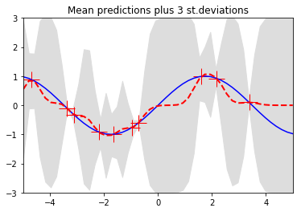

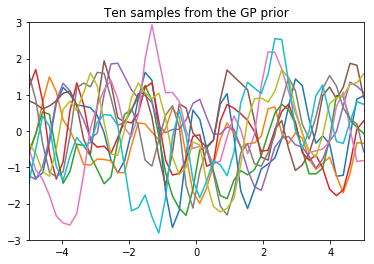

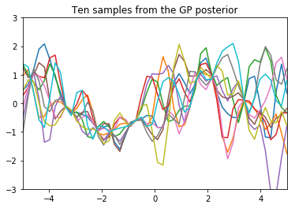

```python
from __future__ import division
import numpy as np
import matplotlib.pyplot as pl

""" This is code for simple GP regression. It assumes a zero mean GP Prior """


# This is the true unknown function we are trying to approximate
f = lambda x: np.sin(0.9*x).flatten()
#f = lambda x: (0.25*(x**2)).flatten()


# Define the kernel
def kernel(a, b):
    """ GP squared exponential kernel """
    kernelParameter = 0.1
    sqdist = np.sum(a**2,1).reshape(-1,1) + np.sum(b**2,1) - 2*np.dot(a, b.T)
    return np.exp(-.5 * (1/kernelParameter) * sqdist)

N = 10         # number of training points.
n = 50         # number of test points.
s = 0.00005    # noise variance.

# Sample some input points and noisy versions of the function evaluated at
# these points.
X = np.random.uniform(-5, 5, size=(N,1))
y = f(X) + s*np.random.randn(N)

K = kernel(X, X)
L = np.linalg.cholesky(K + s*np.eye(N))

# points we're going to make predictions at.
Xtest = np.linspace(-5, 5, n).reshape(-1,1)

# compute the mean at our test points.
Lk = np.linalg.solve(L, kernel(X, Xtest))
mu = np.dot(Lk.T, np.linalg.solve(L, y))

# compute the variance at our test points.
K_ = kernel(Xtest, Xtest)
s2 = np.diag(K_) - np.sum(Lk**2, axis=0)
s = np.sqrt(s2)


# PLOTS:
pl.figure(1)
pl.clf()
pl.plot(X, y, 'r+', ms=20)
pl.plot(Xtest, f(Xtest), 'b-')
pl.gca().fill_between(Xtest.flat, mu-3*s, mu+3*s, color="#dddddd")
pl.plot(Xtest, mu, 'r--', lw=2)
pl.savefig('predictive.png', bbox_inches='tight')
pl.title('Mean predictions plus 3 st.deviations')
pl.axis([-5, 5, -3, 3])

# draw samples from the prior at our test points.
L = np.linalg.cholesky(K_ + 1e-6*np.eye(n))
f_prior = np.dot(L, np.random.normal(size=(n,10)))
pl.figure(2)
pl.clf()
pl.plot(Xtest, f_prior)
pl.title('Ten samples from the GP prior')
pl.axis([-5, 5, -3, 3])
pl.savefig('prior.png', bbox_inches='tight')

# draw samples from the posterior at our test points.
L = np.linalg.cholesky(K_ + 1e-6*np.eye(n) - np.dot(Lk.T, Lk))
f_post = mu.reshape(-1,1) + np.dot(L, np.random.normal(size=(n,10)))
pl.figure(3)
pl.clf()
pl.plot(Xtest, f_post)
pl.title('Ten samples from the GP posterior')
pl.axis([-5, 5, -3, 3])
pl.savefig('post.png', bbox_inches='tight')

pl.show()
```